# Lab 6-2: Linear Regression

### Objectives:

For this lab you should…

- calculation correlation between variables and make predictions using a regression line.
- Check the underlying assumptions of a linear regression.
- Examine the results of hypothesis tests for parameters of the regression line.

# Part 0: R commands you will need

- gf_point(y ~ x, data = DataSetName) generates a scatterplot with x on the horizontal axis and y on the vertical axis.
- cor(y ~ x, data = DataSetName) will find the correlation between x and y.
- lm(y ~ x, data = DataSetName) will fit the linear model that uses x to predict y. You should name the model object.
- summary(mymodel) will generate summaries of your linear model object.
- plot(mymodel, which = 1) will generate the residuals versus fitted values plot.
- plot(mymodel, which = 2) will generate the qq-plot of the residuals.

# Part 1: Predict Exam Scores using GPA

It has been hypothesized that student GPA’s should be correlated with their scores on achievement exams (ExamScore). These data are collected for a set of 20 students. You will look for a possible linear relationship, compute the correlation coefficient and the regression line.

**TASK 1.0** Run the code below to read in the dataset ‘GPAandExamScores.csv’, available in the Files section of our Canvas course.

|  | ExamScore | GPA |
| --- | --- | --- |
| 1 | 98 | 3.6 |
| 2 | 96 | 2.7 |
| 3 | 94 | 3.1 |
| 4 | 88 | 4.0 |
| 5 | 91 | 3.2 |
| 6 | 77 | 3.0 |

**TASK 1.1** Create a scatterplot to explore the relationship between GPA and Exam Scores, letting Exam Scores be the response variable. Based on your figure, what do you believe would be a good estimate for r, the correlation coefficient?

```
**Response** a good estimate for r is roughly .5 based on the figure
```

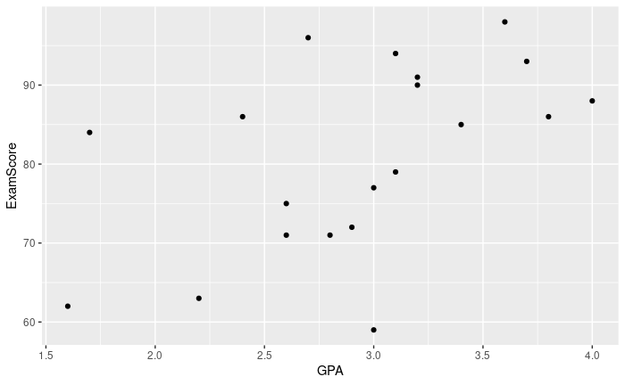

**TASK 1.2** Calculate the correlation coefficient using R and report its value.

```
**Response** r = .524
```

```
[1] 0.5241276
```

**TASK 1.3** Fit the regression line using R. What are the values for $\hat{\beta_0}$ and $\hat{\beta_1}}$?

```
**Response** beta_0 = 52.689 beta_1 = 9.662
```

```
Call:
lm(formula = ExamScore ~ GPA, data = GPA)

Coefficients:
(Intercept)          GPA
     52.689        9.662
```

**TASK 1.4** Write the equation for the regression line to predict Exam Score using GPA.

```
**Response** ExamScore = 52.689 + 9.662 * GPA
```

**TASK 1.5** Would you use this line to predict an achievement score based on a GPA of 3.5? If yes, compute the estimate. If not, explain why.

```
**Response** I would use this line to predict an achievement score based on a GPA of 3.5 as the p-value for the slope of the linear regression model is less
 than the testing level (.05) with a value of .018.  The estimate is 86.506.
```

```
Call:
lm(formula = ExamScore ~ GPA, data = GPA)

Residuals:
    Min      1Q  Median      3Q     Max
-22.676  -6.314  -3.075   8.074  17.222

Coefficients:
            Estimate Std. Error t value Pr(>|t|)
(Intercept)   52.689     11.085   4.753 0.000159 ***
GPA            9.662      3.701   2.611 0.017683 *
---
Signif. codes:  0 ‘***’ 0.001 ‘**’ 0.01 ‘*’ 0.05 ‘.’ 0.1 ‘ ’ 1

Residual standard error: 10.31 on 18 degrees of freedom
Multiple R-squared:  0.2747,    Adjusted R-squared:  0.2344
F-statistic: 6.818 on 1 and 18 DF,  p-value: 0.01768

[1] 86.506
```

# Part 2: Checking the Assumptions

When constructing a linear regression, it is important to consider the residuals. A residual is the distance between the true $y_i$ data point and the predicted $\hat{y_i}$. Use the Assumptions.csv dataset from Canvas for this Section.

You will create a regression line and determine if the data are appropriate for a linear regression model.

**TASK 2.0** Run the code below to read in the dataset ‘Assumptions.csv’, available in the Files section of our Canvas course.

|  | X | Y |
| --- | --- | --- |
| 1 | 0.0 | 8.4056 |
| 2 | 0.2 | 12.2753 |
| 3 | 0.4 | 13.9155 |
| 4 | 0.6 | 16.7357 |
| 5 | 0.8 | 18.6426 |
| 6 | 1.0 | 20.1584 |

**TASK 2.1** Create a scatterplot relating X and Y from the assumptions data. Based on what you observed, does the relationship between X and Y appear linear?

```
**Response** The relationship between X and Y appears to be highly linear.
```

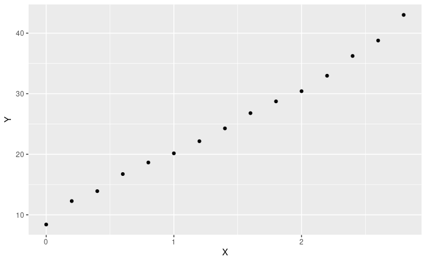

**TASK 2.2** What is the correlation coefficient for these data?

```
**Response** r = .996
```

```
[1] 0.9959896
```

**TASK 2.3** What is the equation of the least squares line predicting Y using X?

```
**Response** Y = 9.028 + 11.337 * X
```

```
Call:
lm(formula = Y ~ X, data = mydata)

Coefficients:
(Intercept)            X
      9.028       11.337
```

**TASK 2.4** Create the fitted values vs residuals plot. Does this figure suggest that the linearity condition is met?

```
**Response** This residuals vs fitted values plot suggests that the linearity condition is not met as there is a clear pattern in the data.
```

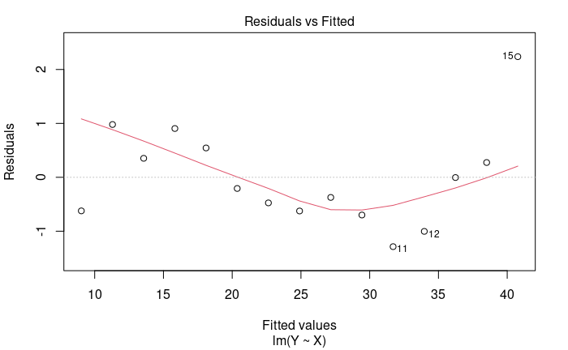

**TASK 2.5** Create the normal probability plot of the residuals. Does it suggest that the residuals are normally distributed? Explain.

```
**Response** This pplot suggests that the residuals are normally distributed because the majority of data points except for a few outliers hug the qi = zi line of
the probability plot.
```

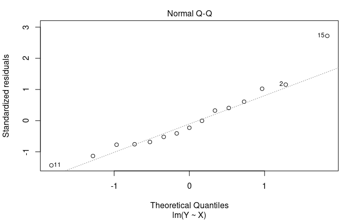

# Part 3: Multiple predictors

We have been constructing linear regression models with one predictor. We will explore a few options for how to choose a model if multiple predictors are available. For this portion, you will need to call in the CarsData.csv dataset, available on Canvas.

**TASK 3.0** Use the code below to read the data into your workspace and explore the first six rows of the data. There is a column for MPG (miles per gallon), WT (weight of the car), and HP (horsepower of the car). Both WT and HP may be good predictors of miles per gallon in a car.

|  | MPG | WT | HP |
| --- | --- | --- | --- |
| 1 | 16.9 | 4.360 | 155 |
| 2 | 15.5 | 4.054 | 142 |
| 3 | 19.2 | 3.605 | 125 |
| 4 | 18.5 | 3.940 | 150 |
| 5 | 30.0 | 2.155 | 68 |
| 6 | 27.5 | 2.560 | 95 |

**TASK 3.1** Create a linear regression model that predicts miles per gallon with weight.

```
Call:
lm(formula = MPG ~ WT, data = cars)

Residuals:
    Min      1Q  Median      3Q     Max
-5.4595 -1.9004  0.1686  1.4032  6.4091

Coefficients:
            Estimate Std. Error t value Pr(>|t|)
(Intercept)   48.708      1.954   24.93  < 2e-16 ***
WT            -8.365      0.663  -12.62 8.89e-15 ***
---
Signif. codes:  0 ‘***’ 0.001 ‘**’ 0.01 ‘*’ 0.05 ‘.’ 0.1 ‘ ’ 1

Residual standard error: 2.851 on 36 degrees of freedom
Multiple R-squared:  0.8155,    Adjusted R-squared:  0.8104
F-statistic: 159.2 on 1 and 36 DF,  p-value: 8.889e-15


Call:
lm(formula = MPG ~ WT, data = cars)

Coefficients:
(Intercept)           WT
     48.707       -8.365
```

Complete the table below with R-squared and the p-value for the coefficient of weight ($H_0:\beta_1 = 0$):

| R-squared | Weight |
| --- | --- |
| .8155 | 8.89e-15 |

Do you believe that weight is a reasonable predictor for miles per gallon? Explain.

```
**Response**  The Wieght is a reasonable predictor for the miles per gallon as the R-squared of .8155 showed strong correlation with a p-value of
              essentially zero allowing us to reject the null beta_1 = 0 and accept H1 which demonstrates correlation.
```

**TASK 3.2** Now create a linear regression model that predicts miles per gallon using horsepower.

```
Call:
lm(formula = MPG ~ HP, data = cars)

Residuals:
    Min      1Q  Median      3Q     Max
-7.5709 -1.9827 -0.4902  1.3827  6.9005

Coefficients:
            Estimate Std. Error t value Pr(>|t|)
(Intercept) 46.70665    2.12702   21.96  < 2e-16 ***
HP          -0.21571    0.02025  -10.65 1.12e-12 ***
---
Signif. codes:  0 ‘***’ 0.001 ‘**’ 0.01 ‘*’ 0.05 ‘.’ 0.1 ‘ ’ 1

Residual standard error: 3.258 on 36 degrees of freedom
Multiple R-squared:  0.7591,    Adjusted R-squared:  0.7524
F-statistic: 113.5 on 1 and 36 DF,  p-value: 1.12e-12


Call:
lm(formula = MPG ~ HP, data = cars)

Coefficients:
(Intercept)           HP
    46.7066      -0.2157
```

Complete the table below with R-squared and the p-value for the coefficient of horsepower ($H_0:\beta_1 = 0$):

| R-squared | Horsepower |
| --- | --- |
| .759 | 1.12e-12 |

Do you believe that horsepower is a reasonable predictor for miles per gallon? Explain.

```
**Response** Horsepower is also a reasonable predictor for miles per gallon demonstrating a strong correlation with a R-Squared of .7591 and a p-value
             of 0 allowing us to reject the null and accept the alternative demonstrating correlation.
```

**TASK 3.3** Use the code below to fit a model that uses both horsepower and weight to predict miles per gallon. Generate the model summary.

```
Call:
lm(formula = MPG ~ WT + HP, data = cars)

Residuals:
    Min      1Q  Median      3Q     Max
-4.5754 -1.7809 -0.0461  1.5237  6.0916

Coefficients:
            Estimate Std. Error t value Pr(>|t|)
(Intercept) 48.94199    1.92398  25.438  < 2e-16 ***
WT          -6.06455    1.63381  -3.712 0.000712 ***
HP          -0.06703    0.04367  -1.535 0.133815
---
Signif. codes:  0 ‘***’ 0.001 ‘**’ 0.01 ‘*’ 0.05 ‘.’ 0.1 ‘ ’ 1

Residual standard error: 2.799 on 35 degrees of freedom
Multiple R-squared:  0.8272,    Adjusted R-squared:  0.8173
F-statistic: 83.76 on 2 and 35 DF,  p-value: 4.554e-14
```

Complete the table below with R-squared and the p-values for the coefficients:

| R-squared | Horsepower | Weight |
| --- | --- | --- |
| .8272 | 0.133815 | 0.000712 |

Do you believe that both weight and horsepower are reasonable predictors for miles per gallon in this model? Explain.

```
**Response**  The p-value for the horsepower was .133815 which prevents us from rejecting the null hypothesis and proving correlation, therefore it is not a reasonable
predictor for MPG.  weight on the other hand had a much smaller p-value of 0.000712 which allows us to reject the null hypothesis, proving correlation.  It is therefore a
reasonable predictor of MPG
```

**TASK 3.4** Of the three models you created, which has the highest coefficient of determination?

```
**Response** The Combined model had the highest coefficient of determination.
```

**TASK 3.5** What is your preferred model for predicting miles per gallon? Explain.

```
**Response** The preferred model is the MPG based on weight.  As shown in the combined model the HP was an ineffective predictor of MPG and gave a very minimal increase to
the coefficient of determination while greatly increasing complexity.  Therefore, it was chosen to weight simplicity over very minor improvements in coefficient of
determination
```